# MAT02014 - Planejamento de Experimentos II Introdução aos delineamentos fatoriais (cont.)

Rodrigo Citton P. dos Reis `rodrigocpdosreis@gmail.com` Universidade Federal do Rio Grande do Sul Instituto de Matemática e Estatística Departamento de Estatística

Porto Alegre, 2018

# Análise estatística do modelo de efeitos fixos

## Relembrando

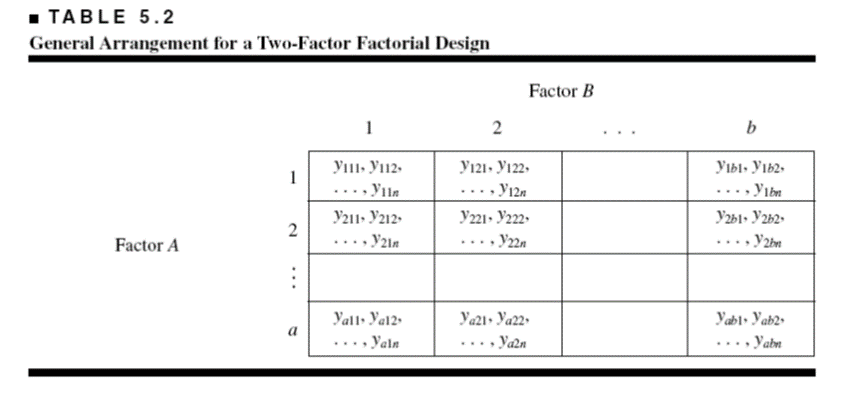

- O **modelo de efeitos**:

$$y_{ijk} = \mu + \tau_i + \beta_j + (\tau\beta)_{ij} + \epsilon_{ijk}, i = 1, \ldots, a, j = 1,\ldots, b, k = 1, \ldots, n.$$

## Somas de quadrados

- $y_{i..}$ denota o total de todas as observações sob o $i$-ésimo nível do fator $A$;
- $y_{.j.}$ denota o total de todas as observações sob o $j$-ésimo nível do fator $B$;
- $y_{ij.}$ denota o total de todas as observações na $ij$-ésima célula;
- $y_{...}$ denota o total global de todas as observações.

## Somas de quadrados

- Defina $\bar{y}_{i..}$, $\bar{y}_{.j.}$, $\bar{y}_{ij.}$ e $\bar{y}_{...}$ como as correspondentes médias da linha, coluna, célula e global:

$$y_{i..} = \sum_{j=1}^b{\sum_{k=1}^n{y_{ijk}}}\quad \bar{y}_{i..} = \frac{y_{i..}}{bn}, i = 1,2,\ldots, a$$

$$y_{.j.} = \sum_{i=1}^a{\sum_{k=1}^n{y_{ijk}}}\quad \bar{y}_{.j.} = \frac{y_{i..}}{an}, j = 1,2,\ldots, b$$

$$y_{ij.} = \sum_{k=1}^n{y_{ijk}}\quad \bar{y}_{ij.} = \frac{y_{ij.}}{n}, i = 1,2,\ldots, a, j = 1,2,\ldots, b$$

$$y_{...} = \sum_{i=1}^a{\sum_{j=1}^b{\sum_{k=1}^n{y_{ijk}}}}\quad \bar{y}_{...} = \frac{y_{...}}{abn}$$

## Somas de quadrados

- A **soma de quadrados total** deve ser escrita como:

$$\begin{eqnarray}
\sum_{i=1}^a{\sum_{j=1}^b{\sum_{k=1}^n{\left(y_{ijk} - \bar{y}_{...}\right)^2}}} &=& bn\sum_{i=1}^a{\left(\bar{y}_{i..} - \bar{y}_{...}\right)^2} + an\sum_{j=1}^b{\left(\bar{y}_{.j.} - \bar{y}_{...}\right)^2}\\
&& n\sum_{i=1}^a{\sum_{j=1}^b{\left(\bar{y}_{ij.} - \bar{y}_{i..} - \bar{y}_{.j.} + \bar{y}_{...}\right)^2}}\\
&& \sum_{i=1}^a{\sum_{j=1}^b{\sum_{k=1}^n{\left(y_{ijk} - \bar{y}_{...}\right)^2}}}
\end{eqnarray}$$

$$SS_T = SS_A + SS_B + SS_{AB} + SS_E.$$

## Graus de liberdade

| Efeito | Graus de liberdade |
| --- | --- |
| A | a - 1 |
| B | b - 1 |
| AB | (a - 1)(b - 1) |
| Erro | ab(n - 1) |
| Total | abn - 1 |

## Quadrados médios

- Cada soma de quadrados dividida por seus graus de liberdade é um **quadrado médio**.
  - Os valores esperados dos quadrados médios são:

$$E[MS_A] = E\left[\frac{SS_A}{a-1}\right] = \sigma^2 + \frac{bn\sum_{i=1}^a{\tau_i^2}}{a-1}$$

$$E[MS_B] = E\left[\frac{SS_B}{b-1}\right] = \sigma^2 + \frac{an\sum_{j=1}^b{\beta_j^2}}{b-1}$$

$$E[MS_{AB}] = E\left[\frac{SS_{AB}}{(a-1)(b-1)}\right] = \sigma^2 + \frac{n\sum_{i=1}^a{\sum_{j=1}^b{(\tau\beta)_{ij}^2}}}{(a-1)(b-1)}$$

$$E[MS_E] = E\left[\frac{SS_E}{ab(n-1)}\right] = \sigma^2$$

## Análise de variância

- Note que se a hipótese nula de *nenhum efeito de tratamento de linha*, *nenhum efeito de tratamento de coluna* e *nenhuma interação*, então $MS_A$, $MS_B$, $MS_{AB}$ e $MS_E$ todos estimam $\sigma^2$.
  - No entanto, se existem diferenças entre os efeitos de tratamento de linha, então $MS_A$ é maior que $MS_E$.
  - De maneira similar, se existem diferenças entre os efeitos de tratamento de coluna, então $MS_B$ é maior que $MS_E$.
- Assim, para testar a significância dos efeitos principais e do efeito de interação, basta dividir o correspondente quadrado médio pelo quadrado médio do erro.
  - Grandes valores desta razão indicam indícios contra a hipótese nula.

## Análise de variância

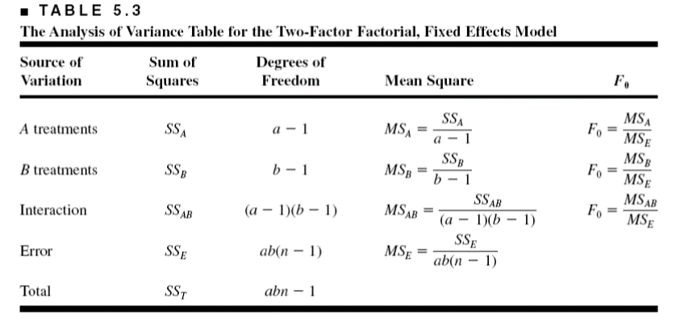

## Exemplo da bateria

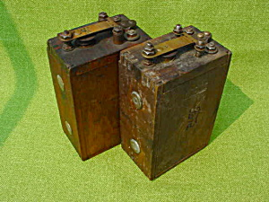

```
##   MT  T   y
## 1  1 15 130
## 2  2 15 150
## 3  3 15 138
## 4  1 70  34
## 5  2 70 136
## 6  3 70 174
```

## Exemplo da bateria

```r
exbat.av <- aov(y ~ MT*T, data = D)
summary(exbat.av)
```

```
##             Df Sum Sq Mean Sq F value   Pr(>F)
## MT           2  10684    5342   7.911  0.00198 **
## T            2  39119   19559  28.968 1.91e-07 ***
## MT:T         4   9614    2403   3.560  0.01861 *
## Residuals   27  18231     675
## ---
## Signif. codes:  0 '***' 0.001 '**' 0.01 '*' 0.05 '.' 0.1 ' ' 1
```

## Exemplo da bateria

```r
model.tables(exbat.av, type = "means", se = F)
```

```
## Tables of means
## Grand mean
##
## 105.5278
##
##  MT
## MT
##      1      2      3
##  83.17 108.33 125.08
##
##  T
## T
##     15     70    125
## 144.83 107.58  64.17
##
##  MT:T
##    T
## MT  15     70     125
##   1 134.75  57.25  57.50
##   2 155.75 119.75  49.50
##   3 144.00 145.75  85.50
```

## Exemplo da bateria

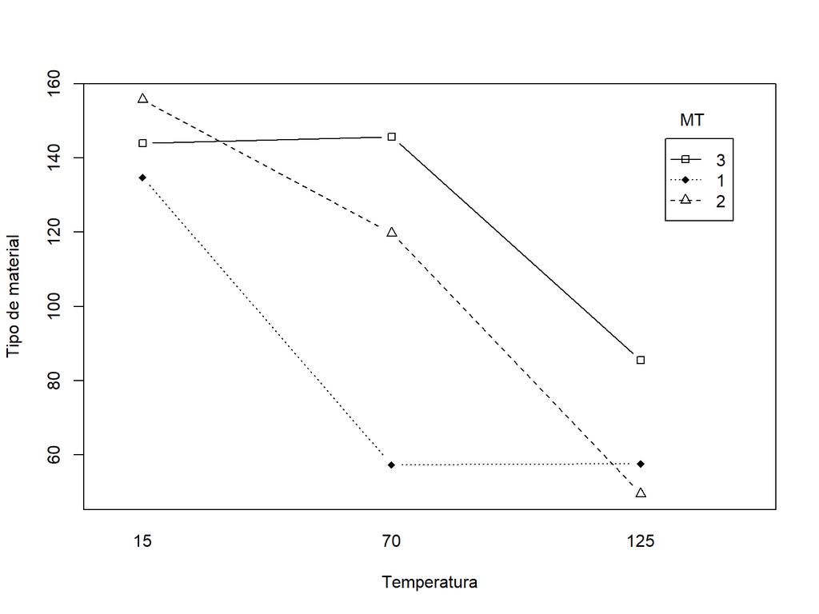

```r
with(D, (interaction.plot(T, MT, y, type = "b", pch = c(18,24,22), leg.bty = "o", main = "", xlab = "Temperatura", ylab = "Tipo de material")))
```

## Exemplo da bateria

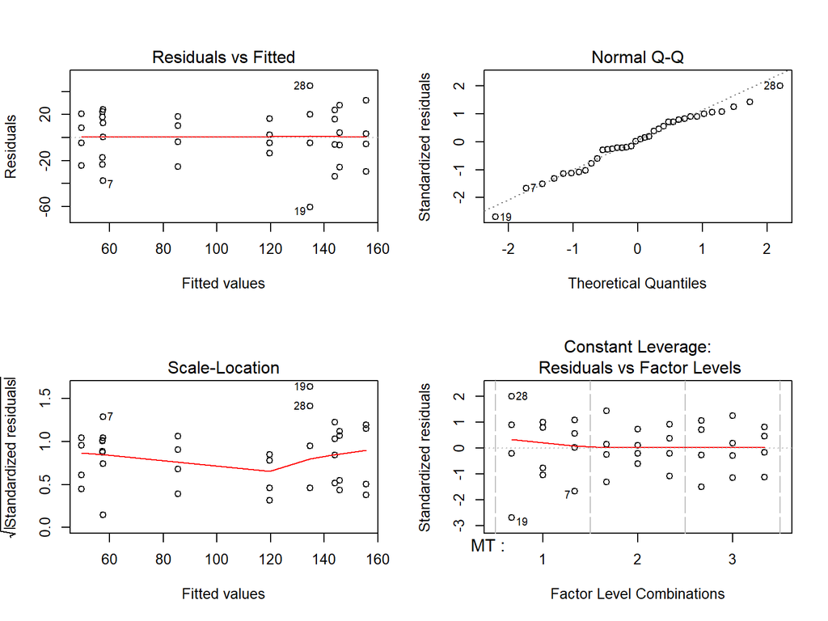

```r
par(mfrow = c(2,2))
plot(exbat.av)
```

## Comparações múltiplas

- Quando a análise de variância indica que as médias de linha ou coluna diferem, usualmente é de interesse fazer comparações entre médias individuais de linha ou coluna para descobrir diferenças específicas.
  - Métodos de comparações múltiplas.

## Comparações múltiplas

### Exemplo da bateria

- Suponha que estejamos interessados em detectar diferenças entre as médias dos três tipos de materiais.
  - Como a interação é significativa, faremos esta comparação em apenas um nível de temperatura (nível 2: 70ºF).
- O **teste de Tukey** pode ser utilizado para comparar os níveis do fator “Tipo de material” mantendo fixa a temperatura.
- Assumiremos que a melhor estimativa para a variância do erro é o $MS_E$.
- Ao nível de significância de 5%

$$T_{0,05} = q_{0,05}(3,27)\sqrt{\frac{MS_E}{n}},$$
em que $q_{0,05}(3,27)$ é o percentil 95% da distribuição $q$ (*distribuição da estatística da amplitude studentizada*) com três comparações e 27 graus de liberdade (associados ao $MS_E$).

## Comparações múltiplas

```r
qtukey(0.95, 3, 27) * sqrt(sum(exbat.av$residuals^2)/(3*3*3)/4)
```

```
## [1] 45.557
```

```r
model.tables(exbat.av, "means")$tables$`MT:T`[,2][3] - model.tables(exbat.av, "means")$tables$`MT:T`[,2][c(2,1)]
```

```
##    2    1
## 26.0 88.5
```

```r
model.tables(exbat.av, "means")$tables$`MT:T`[,2][2] - model.tables(exbat.av, "means")$tables$`MT:T`[,2][c(1)]
```

```
##    2
## 62.5
```

## Para casa (para aula)

- Realize o procedimento de comparações múltiplas para comparar as médias dos tipos de materiais nos outros níveis de temperatura.
- Realize o procedimento de comparações múltiplas para comparar as médias das temperaturas fixando os níveis de tipo de material.
- Pense de que outra forma você poderia avaliar a estatística de teste $F_0$.
  - Implemente sua ideia.

[figure not shown]